# Constructing Confidence Intervals around Proxy Parameters Derived from Vertebrate Isotopes

Matthew Allen

December 2023

# Introduction

#### I will flesh this out in the coming week. I’ll introduce what I’m doing and why I’m doing it. I might suggest how this document/procedure might be used on future analyses.

Uncertainty of proxy estimates derived from vertebrate isotopes is influenced by sample size. It is important to test the sensitivity of a parameter to the number of specimens sampled for an analysis.

First, I will demonstrate how sample size might affect temperature estimates using simulated data based on an empirical dataset from a single assemblage in the Albian (mid-Cretaceous) of Montana.

I will also run resampling simulations on the empirical data and construct confidence intervals on the temperature estimate.

## Demonstration 2: Monte Carlo on empirical data, dual-taxon temperature reconstruction

- Summary:
  1. Generate random resamples of varying sample from empirical data, gather summary statistics for each resample
  2. Compute $\delta$<sup>18</sup>O<sub>ambient_water</sub> distribution
  3. Compute temperature distribution from $\delta$<sup>18</sup>O<sub>ambient_water</sub> and $\delta$<sup>18</sup>O<sub>phosphate_fish</sub>
  4. Construct 95% confidence interval around mean of temperature distribution

#### Setup: Install/load packages, read data, clean and group data by eco-type

Before we begin the procedure, let’s load everything and set up our data. We will also check for normality of the data, and visualize the distribution of each eco-type

#### !!! Recompile NIST120c data, include run 3 !!!

#### !!! Output Shapiro-Wilk test results in table plot so it is visible in Rmarkdown !!!

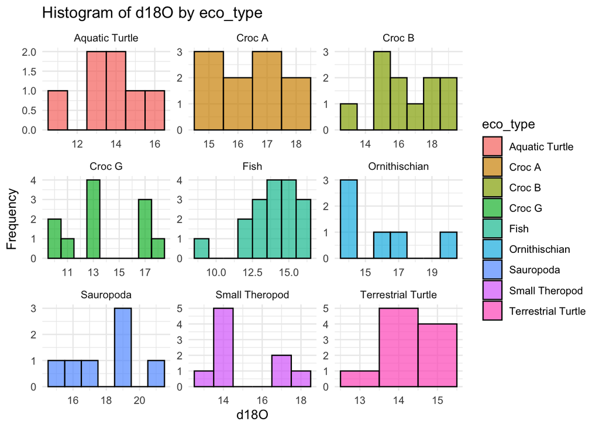

```r
# Packages, Data, Objects -------------------------------------------------

  # Define required packages
    packages <- c("dplyr", "ggplot2", "readr", "magrittr", "tidyr", "purrr")

  # Create function to check, install, and load packages
    check_and_install_packages <- function(packages) {
      missing_packages <- setdiff(packages, installed.packages()[,"Package"])
      if (length(missing_packages) > 0) install.packages(missing_packages, dependencies = TRUE)
      sapply(packages, function(pkg) {
        if (!requireNamespace(pkg, quietly = TRUE)) {
          message(paste("Installing and loading", pkg))
          install.packages(pkg, dependencies = TRUE)
        }
        library(pkg, character.only = TRUE)
      })
    }

  # Run the package function
    check_and_install_packages(packages)

  # Data
    # Call d18Op data from GitHub, cleaned and averaged per specimen (V1075_BySpec.csv)
      samples_githubURL <- "https://raw.githubusercontent.com/mattgeo1990/1075_Vertebrate_d18Op/main/Data/V1075_BySpec.csv"
      V1075_BySpec <- read_csv(samples_githubURL)

    # READ IN NIST120c STD d18Op VALUES FROM RUN 1 and RUN 2
      # NEED NIST120C STD d18Op from Run 3!!!!!
        standards_githubURL <-"https://raw.githubusercontent.com/mattgeo1990/1075_Vertebrate_d18Op/main/Data/V1075_NIST120c.csv"
        NIST120c <- read_csv(standards_githubURL)
        # gather mean
        NIST120c_mean <- mean(NIST120c$d.18O.16O)

  # Final Cleaning, Group by Eco-type
    # Omit Large Theropod and Sharks. Too few data and possible diagenetic influence
      V1075_MC <- subset(V1075_BySpec, eco_type != "Large Theropod" & eco_type != "Shark")

    # Group by eco_type
      grouped_data <- V1075_MC %>% group_by(eco_type)

  # Look at your data
    # Plotting a panel of histograms by eco_type
      p <- ggplot(grouped_data, aes(x = d18O, fill = eco_type)) +
        geom_histogram(binwidth = 1, color = "black", alpha = 0.7) +
        labs(title = "Histogram of d18O by eco_type",
             x = "d18O",
             y = "Frequency") +
        theme_minimal() +
        facet_wrap(~eco_type, scales = "free")

    # Perform Shapiro-Wilk test for normality for each eco_type
      shapiro_tests <- by(grouped_data$d18O, grouped_data$eco_type, shapiro.test)

    # Display normality test results
      cat("\nNormality Tests:\n")
      print(shapiro_tests)

    # Extract p-values from the test results
      p_values <- sapply(shapiro_tests, function(x) x$p.value)

    # Highlight non-normally distributed groups (p-value < 0.05)
      non_normal_groups <- names(p_values[p_values < 0.05])
      cat("\nNon-normally distributed groups:", ifelse(length(non_normal_groups) > 0, paste(non_normal_groups, collapse = ", "), "None"), "\n")

    # Print the ggplot object
      print(p)
```

[output not shown]

### Step 1: Simulate d18Ophosphate data for each eco_type based on distributions of emperical data.

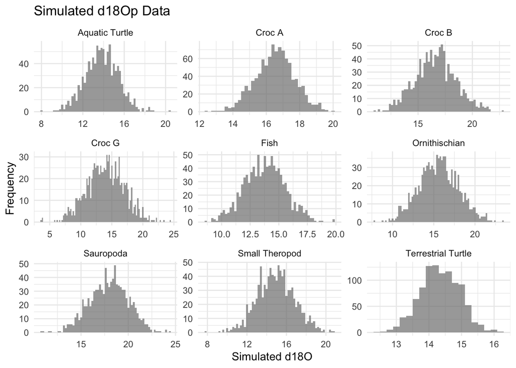

```r
# Simulate dataset ------------------------------------------------------

  # Function to generate simulated dataset for a given eco_type
    simulate_eco_type <- function(subset_data, n_simulations = 1000) {
      mean_val <- mean(subset_data$d18O)
      sd_val <- sd(subset_data$d18O)

      simulated_values <- replicate(n_simulations, rnorm(1, mean_val, sd_val))
      return(simulated_values)
    }

  # Generate simulated datasets for each eco_type
    simulated_data <- grouped_data %>%
      summarise(simulated_d18O = list(simulate_eco_type(cur_data(), n_simulations = 1000))) %>%
      unnest(simulated_d18O)

  # Check the structure of the simulated_data
    str(simulated_data)

  # Plot histograms of the simulated data to compare against the empirical data
    ggplot(simulated_data, aes(x = simulated_d18O, fill = eco_type)) +
      geom_histogram(binwidth = 0.2, position = "identity", alpha = 0.7) +
      labs(title = "Simulated d18Op Data", x = "Simulated d18O", y = "Frequency") +
      scale_fill_manual(values = c("A" = "blue", "B" = "green")) +
      facet_wrap(~eco_type, scales = "free") +
      theme_minimal()
```

[output not shown]

```r
# Resampling simulated data--------------------------------------------------------------

     # Function to generate resamples for a given eco_type
    generate_resamples <- function(subset_data, sample_sizes = c(5, 10, 15, 20), n_resamples = 1000) {
      resampled_data <- lapply(sample_sizes, function(sample_size) {
        resamples <- replicate(n_resamples, sample(subset_data$d18O, size = sample_size, replace = TRUE))
        means <- colMeans(resamples)
        variances <- apply(resamples, 2, var)
        standard_errors <- apply(resamples, 2, function(x) sd(x) / sqrt(length(x)))
        standard_deviations <- apply(resamples, 2, sd)

        data.frame(
          sample_size = rep(sample_size, each = n_resamples),
          sim_d18Op_mean = means,
          sim_d18Op_var = variances,
          sim_d18Op_SE = standard_errors,
          sim_d18Op_SD = standard_deviations
        )
      })

      return(do.call(rbind, resampled_data))
    }


    # Generate resamples for each eco_type
    resampled_data <- grouped_data %>%
      group_modify(~ generate_resamples(.x, n_resamples = 1000))

    # Assuming resampled_data is the output from generate_resamples function
    resamples <- list()

    sample_sizes <- unique(resampled_data$sample_size)

    for (size in sample_sizes) {
      resamples[[paste0("sample_size_", size)]] <- subset(resampled_data, sample_size == size)
    }

    # Now, each subset is stored in resamples list
    # Access them using resamples$sample_size_5, subsetted_data$sample_size_10, etc.
```

### Step 3: Compute $\delta$<sup>18</sup>O<sub>ambient_water</sub>

Here we are calculating $\delta$<sup>18</sup>O<sub>ambient_water</sub> from $\delta$<sup>18</sup>O<sub>phosphate</sub> of the aquatic turtle *Glyptops sp.* and a aquatic/semi-aquatic crocodylomorph morphotype referred to as “Croc G”. These equations are from Barrick et al. (1999) and Amiot et al. (2007), respectively.

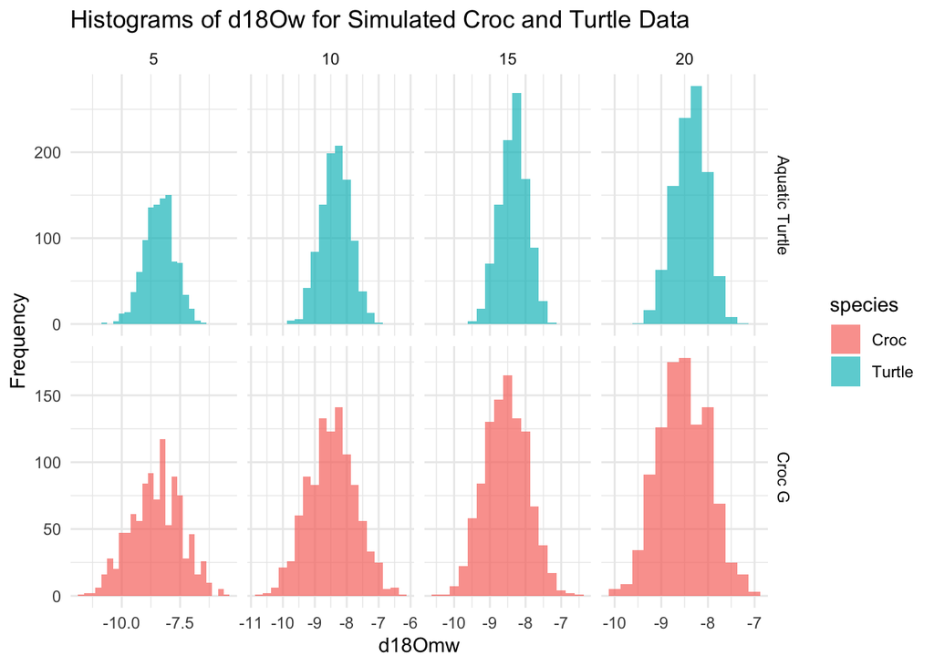

```r
  # Define d18Omw functions

    # d18Omw from croc d18Op (Amiot et al., 2007)
      crocwater <- function(mean_d18Op) {
        result <- 0.82 * mean_d18Op - 19.93
        return(data.frame(d18Omw = result))
      }

    # d18Omw from turtle d18Op (Barrick et al., 1999)
      turtlewater <- function(mean_d18Op) {
        result <- 1.01 * mean_d18Op - 22.3
        return(data.frame(d18Omw = result))
      }

  # Subset sim data by eco_type

    # Croc G
      # Subset resamples and extract Croc G rows
        croc_subsets <- lapply(resamples, function(df) subset(df, eco_type == "Croc G"))
      # Combine the Croc G subsets into a single data frame
        sim_croc <- do.call(rbind, croc_subsets)
      # Add d18Omw column to sim_croc
        sim_croc$d18Omw <- NA

    # Aquatic Turtle
      # Subset resamples and extract Aquatic Turtle rows
        turtle_subsets <- lapply(resamples, function(df) subset(df, eco_type == "Aquatic Turtle"))
      # Combine the Aquatic Turtle subsets into a single data frame
        sim_turtle <- do.call(rbind, turtle_subsets)
      # Add d18Omw column to sim_turtle
        sim_turtle$d18Omw <- NA

  # Compute d18O water values
    # Compute d18Omw from turtle d18Op
      sim_turtle$d18Omw <- turtlewater(sim_turtle$sim_d18Op_mean)$d18Omw
    # Compute d18Omw from croc d18Op
      sim_croc$d18Omw <- crocwater(sim_croc$sim_d18Op_mean)$d18Omw



  # Plot histograms to look at d18Omw distributions

    # Combine sim_croc and sim_turtle into a single data frame for easier plotting
      combined_data <- rbind(cbind(sim_croc, species = "Croc"), cbind(sim_turtle, species = "Turtle"))

    # Plot histograms for each combination of eco_type and sample_size
      plot_panel <- ggplot(combined_data, aes(x = d18Omw, fill = species)) +
        geom_histogram(binwidth = 0.25, position = "dodge", alpha = 0.7) +
        facet_grid(eco_type ~ sample_size, scales = "free") +
        labs(title = "Histograms of d18Ow for Simulated Croc and Turtle Data",
             x = "d18Omw", y = "Frequency") +
        theme_minimal()

    # Display the plot
      print(plot_panel)
```

### Step 4: Compute dual-taxon temperature estimates

##### This is bricking my computer. I have not yet been able to successfully compute a temperature distribution. See “Dual-taxon Temperature Estimates” in “V1075_MonteCarloBootstrap.R”

##### Note about which taxon to use as proxy for $\delta$<sup>18</sup>O<sub>ambient_water</sub>

```r
  # Setup

    # Subset resamples and extract Fish rows
      fish_subsets <- lapply(resamples, function(df) subset(df, eco_type == "Fish"))
      # Combine the Fish subsets into a single data frame
      sim_fish <- do.call(rbind, fish_subsets)

      str(sim_fish)
```

```
## gropd_df [4,000 × 6] (S3: grouped_df/tbl_df/tbl/data.frame)
##  $ eco_type      : chr [1:4000] "Fish" "Fish" "Fish" "Fish" ...
##  $ sample_size   : num [1:4000] 5 5 5 5 5 5 5 5 5 5 ...
##  $ sim_d18Op_mean: num [1:4000] 14 13.7 13.5 13.4 14.8 ...
##  $ sim_d18Op_var : num [1:4000] 6.926 5.953 2.696 5.334 0.307 ...
##  $ sim_d18Op_SE  : num [1:4000] 1.177 1.091 0.734 1.033 0.248 ...
##  $ sim_d18Op_SD  : num [1:4000] 2.632 2.44 1.642 2.309 0.554 ...
##  - attr(*, "groups")= tibble [1 × 2] (S3: tbl_df/tbl/data.frame)
##   ..$ eco_type: chr "Fish"
##   ..$ .rows   : list<int> [1:1]
##   .. ..$ : int [1:4000] 1 2 3 4 5 6 7 8 9 10 ...
##   .. ..@ ptype: int(0)
##   ..- attr(*, ".drop")= logi TRUE
```

```r
    # Create fishtemp function (Puceat et al., 2010)
      fishtemp <- function(fish_d18Op, NIST120c_mean, d18Omw) {
      temp <- 118.7 - 4.22 * ((fish_d18Op + (22.6 - NIST120c_mean)) - d18Omw)
      return(temp)
      }

  # Compute temps
      # Get distinct sample sizes
      distinct_sample_sizes <- unique(sim_turtle$sample_size)

      # Function to calculate temperature
      fishtemp <- function(fish_d18Op, NIST120c_mean, d18Omw) {
        temp <- 118.7 - 4.22 * ((fish_d18Op + (22.6 - NIST120c_mean)) - d18Omw)
        return(temp)
      }

      # Create an empty data frame to store results
      result_df <- data.frame(Sample_Size = numeric(),
                              Temperature = numeric())

      # This is where the loop will go which will compute the temps. It is commented out here because the run time is enormous. I'm working on that.

      # Iterate over distinct sample sizes
      #for (sample_size in distinct_sample_sizes) {
        # Subset sim_fish and sim_turtle for the current sample_size
        #subset_sim_fish <- subset(sim_fish, sample_size == sample_size)
        #subset_sim_turtle <- subset(sim_turtle, sample_size == sample_size)

        # Iterate over each combination of sim_fish$sim_d18Op_mean and sim_turtle$d18Omw
        #for (fish_d18Op_mean in subset_sim_fish$sim_d18Op_mean) {
          #for (turtle_d18Omw in subset_sim_turtle$d18Omw) {
            # Call fishtemp for the current combination
           # temperature <- fishtemp(fish_d18Op_mean, 22.6, turtle_d18Omw)

            # Store the result in the data frame
            #result_df <- rbind(result_df, data.frame(Sample_Size = sample_size, Temperature = temperature))
         # }
       # }
     # }

  # Plot temp distributions
      #ggplot(result_df, aes(x = Temperature, fill = as.factor(Sample_Size))) +
        #geom_histogram(position = "identity", alpha = 0.7, bins = 20) +
        #facet_wrap(~Sample_Size, scales = "free") +
        #labs(title = "Histogram of Temperature for Each Sample Size", x = "Temperature", y = "Frequency") +
        #theme_minimal()
```

### Step 5: Construct confidence intervals

```r
# Assuming "data" is your distribution
# Replace "data" with your actual data

# Calculate mean and standard deviation
  # mean_value <- mean(data)
  # sd_value <- sd(data)

# Calculate 95% confidence limits
  # lower_limit <- mean_value + qnorm(0.025) * sd_value
  # upper_limit <- mean_value + qnorm(0.975) * sd_value

# Print the confidence limits
  # cat("95% Confidence Interval: (", lower_limit, ", ", upper_limit, ")\n")
```